# Pakistan: From Stabilization to Transformation

A Growth Diagnostics Brief

Growth Lab, Harvard Kennedy School

April 2026

```r
knitr::opts_chunk$set(echo = FALSE, warning = FALSE, message = FALSE)

library(tidyverse)
library(ggthemes)
library(ggrepel)
library(arrow)
library(showtext)
library(sysfonts)
library(patchwork)
library(scales)

# ---- Growth Lab design tokens ------------------------------------------------

gl <- list(
    text_dark   = "#333333",
    text_muted  = "#7c7c7c",
    border      = "#dcdcdc",
    background  = "#f3f3f3",
    brand_blue  = "#266798",
    palette = c(
        "#266798", "#C64646", "#36B250", "#EAC218", "#D1852A",
        "#52E2DE", "#A42DE2", "#7C6760", "#757777"
    )
)

highlight    <- "#C64646"
highlight_sz <- 1.1

# ---- Fonts -------------------------------------------------------------------

font_add_google("Source Sans 3", "gl_sans")
font_add_google("JetBrains Mono", "gl_mono")
showtext_auto()
showtext_opts(dpi = 300)

# ---- Theme -------------------------------------------------------------------

theme_gl <- function(base_size = 12) {
    theme_few(base_size = base_size) %+replace%
    theme(
        text          = element_text(family = "gl_sans", color = gl$text_dark),
        plot.title    = element_text(family = "gl_sans", face = "plain",
                                     size = rel(1.35), hjust = 0,
                                     margin = margin(b = 4)),
        plot.subtitle = element_text(family = "gl_sans", color = gl$text_muted,
                                     size = rel(1.0), hjust = 0,
                                     margin = margin(b = 10)),
        plot.caption  = element_text(family = "gl_mono", color = gl$text_muted,
                                     size = rel(0.75), hjust = 1,
                                     margin = margin(t = 8)),
        axis.title    = element_text(family = "gl_mono", color = gl$text_muted,
                                     size = rel(0.85)),
        axis.title.x  = element_text(margin = margin(t = 6)),
        axis.title.y  = element_text(margin = margin(r = 6), angle = 90),
        axis.text     = element_text(family = "gl_sans", color = gl$text_dark,
                                     size = rel(0.85)),
        legend.title  = element_text(family = "gl_mono", color = gl$text_muted,
                                     size = rel(0.8)),
        legend.text   = element_text(family = "gl_sans", size = rel(0.85)),
        strip.text    = element_text(family = "gl_mono", color = gl$text_dark,
                                     size = rel(0.85))
    )
}

theme_set(theme_gl())

options(
    ggplot2.discrete.colour = gl$palette,
    ggplot2.discrete.fill   = gl$palette
)

# ---- Figure sizes (from framework.md) ----------------------------------------

gl_fig <- list(
    full        = list(w = 6.5,   h = 4.0),
    full_tall   = list(w = 6.5,   h = 6.0),
    full_square = list(w = 6.5,   h = 6.5),
    major       = list(w = 4.278, h = 4.0),
    half        = list(w = 3.167, h = 3.0),
    half_tall   = list(w = 3.167, h = 5.0)
)

save_fig <- function(name, filename, plot = last_plot(), dpi = 300) {
    sz <- gl_fig[[name]]
    ggsave(file.path("imgs", filename), plot = plot,
           width = sz$w, height = sz$h, dpi = dpi)
}

# ---- Data --------------------------------------------------------------------

macro_df <- read_parquet("~/dev/shared-data/growth-lab/glmacro_master_alldata.parquet")

main_country     <- "PAK"
main_comparators <- c("BGD", "EGY", "IND", "IDN", "LKA", "MAR", "VNM")
```

# Introduction

Pakistan stands at a critical juncture. After decades of boom-bust cycles driven by recurring balance-of-payments crises, the country has entered a new stabilization phase under its latest IMF program. But stabilization alone is not a growth strategy. Without a deliberate shift toward export-led growth and productive diversification, Pakistan risks returning to the same pattern that has kept its per capita income stagnant relative to peers.

This brief presents a diagnostic overview of Pakistan’s macroeconomic trajectory, drawing on data from the IMF, World Bank, and the Atlas of Economic Complexity. It accompanies the Growth Lab’s proposed 18-month engagement with the Ministry of Finance.

# The Macro-Fiscal Picture

## Foreign reserves: a recurring vulnerability

Pakistan’s foreign exchange reserves have repeatedly fallen below the three-month-of-imports threshold considered the minimum for macroeconomic stability. Each episode triggers emergency borrowing, IMF programs, and contractionary adjustment.

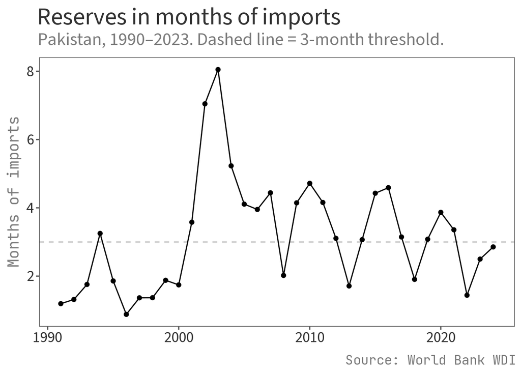

*Source: World Bank World Development Indicators.*

## Growth and the current account constraint

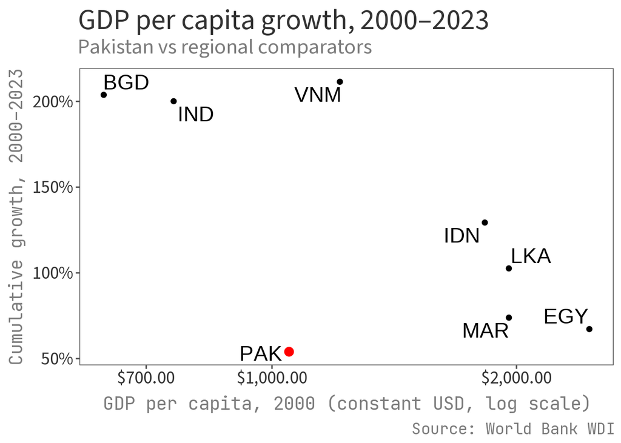

**Figure 2.** GDP per capita growth (2000–2023) against initial income level. Pakistan highlighted in red.

*Source: World Bank WDI. Authors’ calculations.*

## Private credit: a symptom of shallow finance

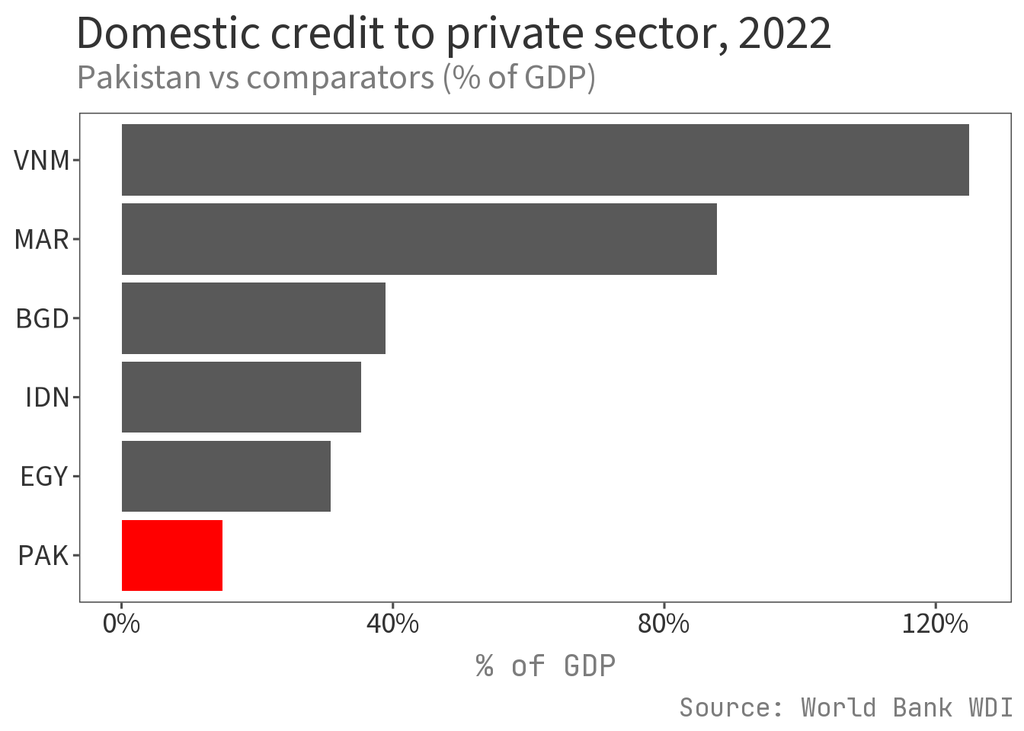

**Figure 3.** Domestic credit to the private sector as a share of GDP, Pakistan vs comparators.

*Source: World Bank WDI.*

# Toward a Growth Strategy

The Growth Lab’s engagement with Pakistan is structured around two pillars:

| Pillar | Focus | Timeline |
| --- | --- | --- |
| Macro-Fiscal Framework | Fiscal space, debt sustainability, SBP | Months 1–8 |
| Export Diversification Strategy | Product space, complexity, industrial policy | Months 4–18 |

Both pillars are supported by an **Action-Learning Team** model that pairs Growth Lab researchers with counterparts in the Ministry of Finance, the Planning Commission, and the State Bank of Pakistan.

> The goal is not to produce a report that sits on a shelf, but to build analytical capacity within government institutions that outlasts the engagement itself.